# Social Networks Analysis - Final Blog Post(er)

Jael Tan

22/12/2021

## Introduction

A stochastic actor-oriented model is fitted on the networks of individuals indirectly and directly associated with the 2000 Christmas Eve Bombings in Indonesia at three ‘time-points’: 1995-1999, 2000, and 2001. This report investigates how the type of partnership between actors in the network changes over time and its relationship with the status of the individuals - whether they are free, arrested, or dead. This may be influenced by the structure of the network and the existing ties between actors, as well as exogenous factors like kinship ties.

As the 2000 Christmas Eve Bombings in Indonesia were religiously-motivated, it is interesting to investigate if other non-religious factors affect the likelihood of forming collaboration ties. Specifically, whether close kinship ties fosters ties of close collaboration among actors, and whether the formation of close collaboration ties results in a change (reduction) in freedom status (eg. from free to arrested or from free to dead).

## Model Choice and Data

As the network data of interest here is longitudinal data on a group of actors and their ties to one another at three time points (‘waves’), a stochastic actor-oriented model (SAOM) is used here to analyse the co-evolution of a one-mode undirected network and individual behaviour, specifically the type of partnership between actors involved in the 2000 Bombings and their freedom status. SAOMs are based on the assumption that the network evolves from a stochastic process in which actors make choices regarding their outgoing ties [(Snijders, van de Bundt and Steglich, 2010)](https://doi.org/10.1016/j.socnet.2009.02.004). Likewise, an assumption is made here that the actors involved in the bombings collaborated with one another of their own volition, although their resultant freedom status may be less a direct choice made by the actors than a result of their choices made regarding collaboration.

The data used in the analysis here was retrieved from the [`{networkdata}`](http://networkdata.schochastics.net/) R package. The original data is a set of weighted networks encapsulating information on the type of partnership ties between the actors associated, indirectly or directly, with the 2000 Christmas Eve Bombings in Indonesia from 1990 to 2007 (1 for acquaintances or interaction limited to radical organisation activities; 2 for close collaboration on a bombing; 3 for tight-knit operational cliques). There are a total of 45 actors in the network at each observation. From this data, I have selected only three observations for my analysis: 1995 to 1999, 2000, and 2001. As we can see from the plots, the number of ties increased exponentially in the first period and decreased in the second period. The Jaccard coefficients for both periods are above 0.2, although the coefficient for the second period is much higher at 0.8, showing that the data in the second and third waves adheres more closely to the model’s assumption of gradual change process [(Snijders, van de Bundt and Steglich, 2010)](https://doi.org/10.1016/j.socnet.2009.02.004).

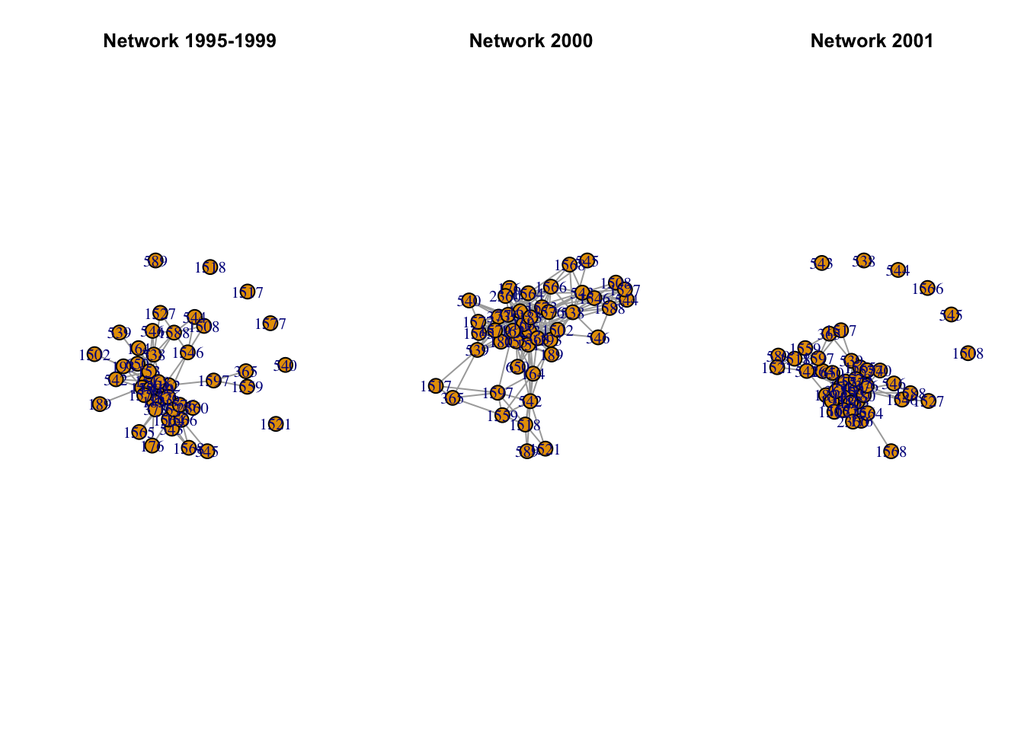

The original data also contains separate networks of kinship ties between the actors that are constant over time. The plots below show kinship ties in each category (unrelated, in-laws, and siblings).

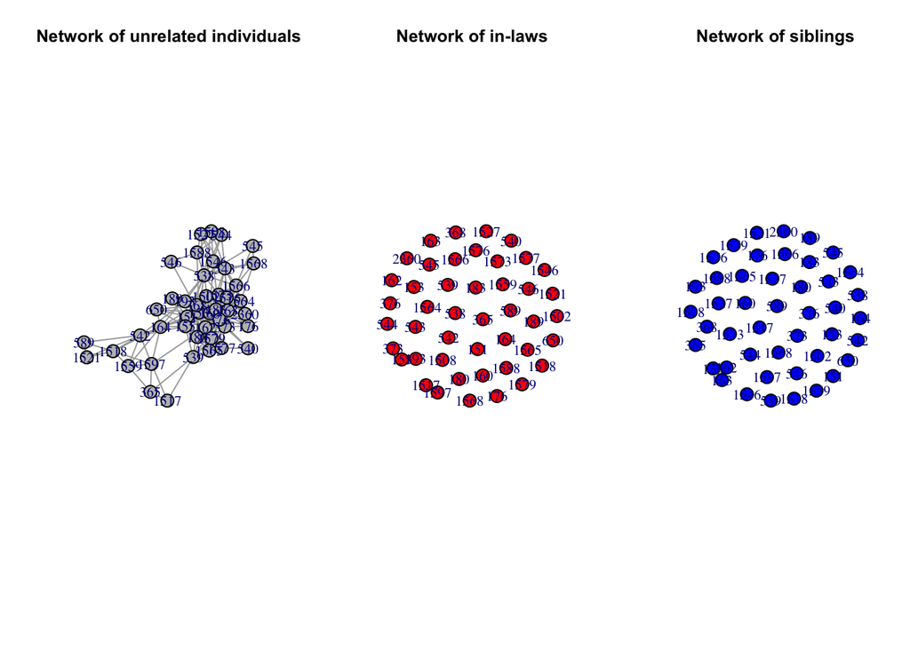

I also included data on the status of the individuals from the [John Jay & ARTIS Transnational Terrorism Database](http://doitapps.jjay.cuny.edu/jjatt/data.php) which indicates whether these individuals are free, arrested, or dead. Higher degree of collaboration may affect the status of individuals after the 2000 bombings. The plots below show the changes in the network with the nodes coloured by their status.

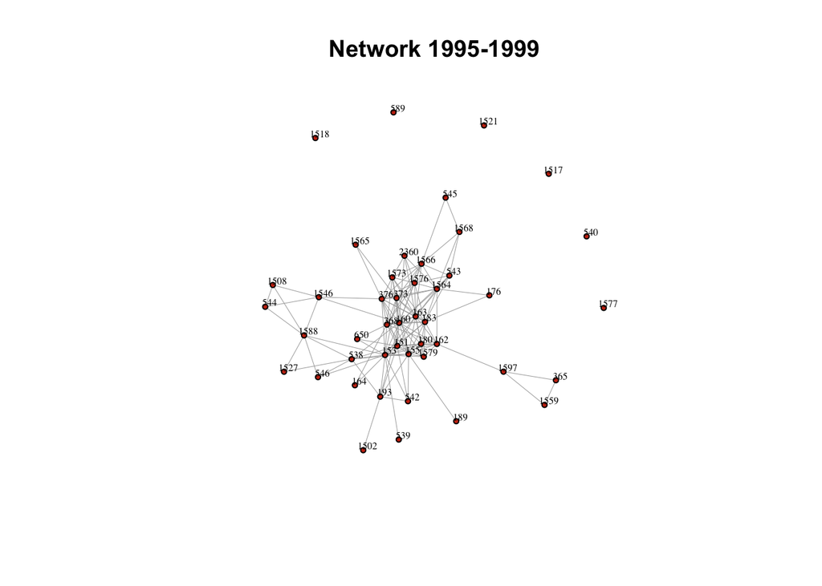

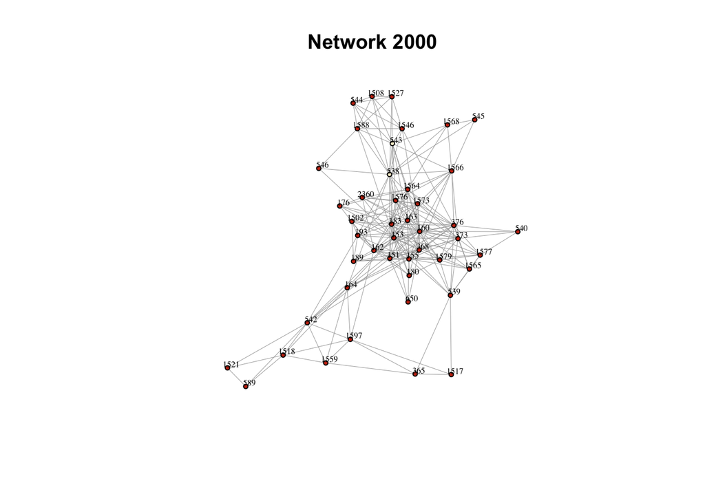

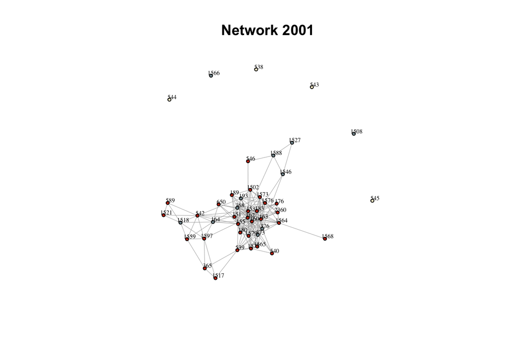

## Modelling and Results

```r
# network data: ties of close collaboration on a bombing
cl_dv <- sienaDependent(array(c(cl1, cl2, cl3), dim = c(45, 45, 3) ),
                        type="oneMode")
# behavioural data: status of actor over time
status <- read.csv("status.csv") %>% as.matrix()
status <- sienaDependent(status[,c(4:6)], type="behavior")

# dyadic time-varying covariate
kinship_iv <- coDyadCovar(as_matrix(kinship))
```

```
## Estimates, standard errors and convergence t-ratios
##
##                                           Estimate   Standard   Convergence
##                                                        Error      t-ratio
## Network Dynamics
##    1. rate constant cl_dv rate (period 1) 14.3444  (  5.9242  )   -0.0177
##    2. rate constant cl_dv rate (period 2)  1.0288  (  0.2314  )   -0.0057
##    3. eval degree (density)               -8.4391  (  6.8491  )   -0.0327
##    4. eval transitive ties                 4.2856  (  1.8030  )   -0.0197
##    5. eval 4-cycles (1)                    0.0640  (  0.5706  )   -0.0511
##    6. eval degree of ego                  -0.2902  (  2.0701  )   -0.0172
##    7. eval kinship_iv                      6.7134  (  2.4919  )   -0.0350
##
## Behavior Dynamics
##    8. rate rate status (period 1)          0.4746  (  0.4939  )   -0.0386
##    9. rate rate status (period 2)          0.9800  (  0.3261  )   -0.0009
##   10. eval status degree                   0.1021  (  0.0943  )   -0.0035
##   11. eval status average alter           12.4402  ( 12.3228  )   -0.0159
##
## Overall maximum convergence ratio:    0.2459
##
##
##  Model Type:
## cl_dv : Initiative model
##
##
## Total of 2108 iteration steps.
```

```
##      Estimates Standard.errors t.statistic
## 1  14.34436169      5.92424684   2.4212971
## 2   1.02877102      0.23142816   4.4453149
## 3  -8.43910596      6.84910773  -1.2321468
## 4   4.28557349      1.80296653   2.3769568
## 5   0.06396388      0.57055450   0.1121083
## 6  -0.29017714      2.07005523  -0.1401785
## 7   6.71335915      2.49188882   2.6940845
## 8   0.47462604      0.49386929   0.9610357
## 9   0.98003754      0.32605944   3.0057021
## 10  0.10208723      0.09427038   1.0829195
## 11 12.44016531     12.32276480   1.0095271
```

From the results of the model, as each of the convergence t-ratios are less than 0.1 in absolute value and the overall maximum convergence ratio (0.246) is less than 0.3, the model has converged and the results can be interpreted.

## Goodness of Fit (GOF) and limitations

Before conducting the goodness of fit tests, we can first compare the plots of the simulated data and the observed data from the last wave of data, here in 2001. At a glance, the simulated network has far more nodes than the observed network.

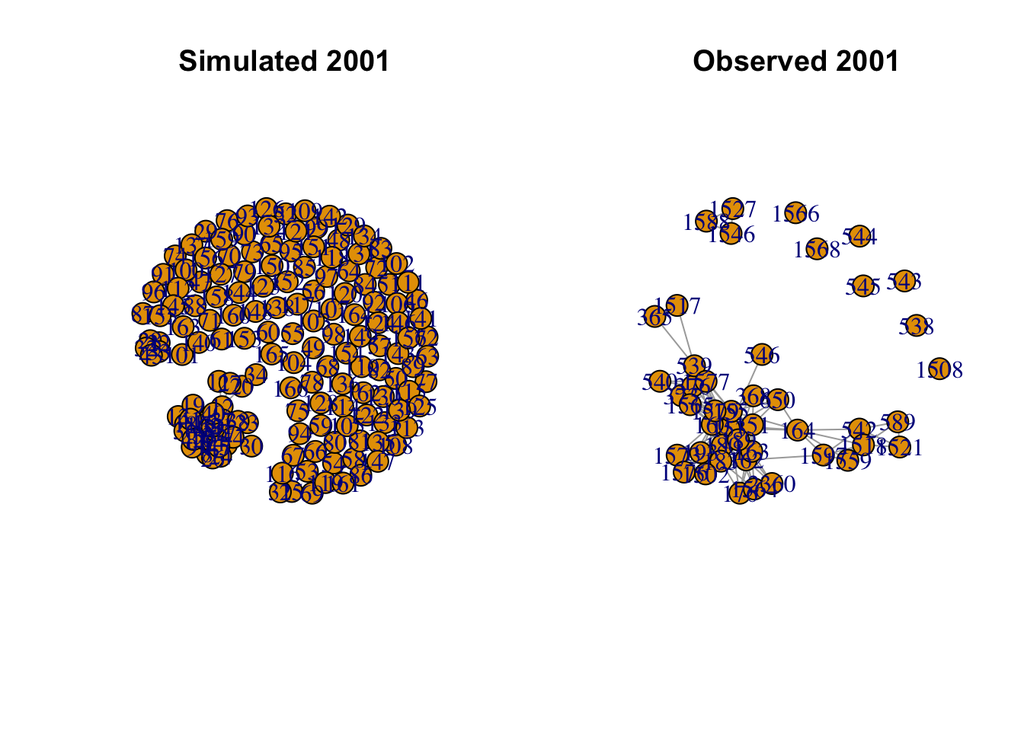

I assess the goodness of fit of the model on the outdegree distribution and the triad census auxiliary statistics [(Lospinoso and Snijders, 2019)](https://journals.sagepub.com/doi/10.1177/2059799119884282). The goodness of fit tests show that the model is a poor fit since the p-values in each case are less than 0.05 [(Ripley, Snijders, Boda, Vörös, and Preciado, 2021)](http://www.stats.ox.ac.uk/%20snijders/siena/). This means that the model which generated the observed data is very unlikely to be equal to the fitted model. The goodness of fit for the outdegree distribution statistic is marginally worse (p-value = 0.002) than the fit for the triad census statistic (p-value = 0.006). When the p-value is less than 0.05 but greater than 0.001, with respect to the auxiliary statistic the distribution of the observed data points do not coincide to a large degree with the simulated data points.

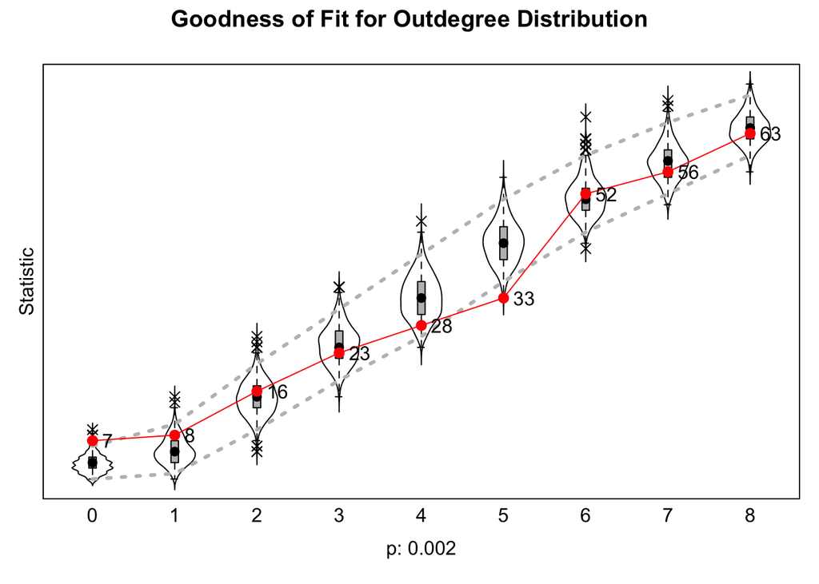

```
## Note: some statistics are not plotted because their variance is 0.
## This holds for the statistics: 012 021D 021U 021C 111D 111U 030T 030C 120D 120U 120C 210.
```

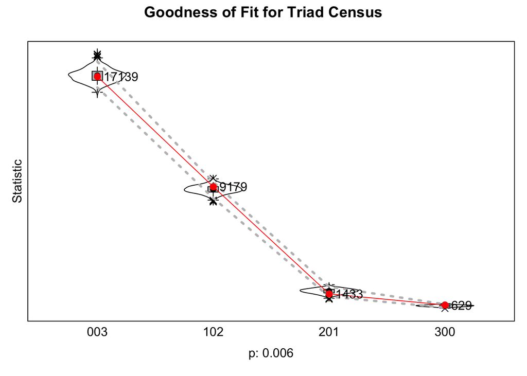

As seen in the violin plots, the simulated statistics (represented by the violin plots) are generally overestimated compared to the observed statistics (indicated by numbers connected by the red line), although there is less discrepancy for the triad census statistic than for the outdegree distribution statistic. The difference between the simulated networks and the observed networks could be attributable to the small number of ties for very close partnerships and other unaccounted effects. The likely presence of effects that are unaccounted for in the current model is largely due to difficulties in converging the model as well as limited theoretical expectations derived from the lack of data on actors and their relationships. To account more fully for these, we would need more information about actor attributes related to their participation in the bombings and information related to the event itself. The presence of an event in 2000 (the bombings) might also have motivated certain changes in ties to the network that would not otherwise be there.